# Determining Cognitive Load difficulty - Pilot Analysis

This is a short script that combines the pilot data files and saves a CSV that you can plot with.

## Loading the Data

First, we want to add the files into one big data frame. For each participant we have two files. One ‘EndofTrial’ file that records counts, and one ‘WithinTrial’ file that records responses to stimuli.

```r
library("tidyverse") #load code libraries for analysis

FilePath <- "~/SP_18-19/Pilot_Data/" #filepath (~ means to look in user's working directory)
Exp_ID <- "Orca18_Pilot_" #experiment code that gets prepended to any data file.
EoT <- "_EndofTrial.csv" #text at end of EndofTrial files
WiT <- "_WithinTrial.csv" #text at end of WithinTrial files
PPs <- 1:3 #vector of participant codes

for (pp in PPs){ #this for loop will loop through our participant vector
  filename_EoT = paste(FilePath,Exp_ID, pp, EoT, sep="") #creates a string from our variables
  filename_WiT = paste(FilePath,Exp_ID, pp, WiT, sep="") #creates a string from our variables

  if (pp == 1){ #if it is the first participant, create a new data frame.

    EoT_dataframe <- read.csv(filename_EoT) #load data
    WiT_dataframe <- read.csv(filename_WiT)

  } else{ #if it isn't the first participant, add loaded files to existing data frame
    EoT_newdata <- read.csv(filename_EoT) #load data
    WiT_newdata <- read.csv(filename_WiT)

    EoT_dataframe <- rbind(EoT_newdata, EoT_dataframe) #add to existing datframe
    WiT_dataframe <- rbind(WiT_newdata, WiT_dataframe) #add to existing datframe
  }
}

head(EoT_dataframe) #view start of dataframe.
```

|  | X | ppid | targetoccurence | targetnumber | trialn | EoTScore1 | TargetCount1 | EoTScore2 | TargetCount2 | EoTScore3 | TargetCount3 |
| --- | --- | --- | --- | --- | --- | --- | --- | --- | --- | --- | --- |
| 1 | 0 | 3 | 0.8 | 2 | 0 | 5 | 5 | 7 | 7 | NA | NA |
| 2 | 1 | 3 | 0.2 | 3 | 1 | 0 | 0 | 0 | 0 | 0 | 0 |
| 3 | 2 | 3 | 0.2 | 1 | 2 | 5 | 5 | NA | NA | NA | NA |
| 4 | 3 | 3 | 0.6 | 2 | 3 | 5 | 4 | 2 | 2 | NA | NA |
| 5 | 4 | 3 | 0.2 | 1 | 4 | 3 | 3 | NA | NA | NA | NA |
| 6 | 5 | 3 | 0.2 | 3 | 5 | 1 | 1 | 1 | 1 | 0 | 0 |

```r
head(WiT_dataframe) #view start of dataframe.
```

|  | X | ppid | targetoccurence | targetnumber | trialn | CurrentAudio | RT | ResponseCategory | Target1 | Target2 | Target3 |
| --- | --- | --- | --- | --- | --- | --- | --- | --- | --- | --- | --- |
| 1 | 0 | 3 | 0.8 | 2 | 0 | o | 1.0326844 | 1 | o | b |  |
| 2 | 1 | 3 | 0.8 | 2 | 0 | b | -1.0000000 | 2 | o | b |  |
| 3 | 2 | 3 | 0.8 | 2 | 0 | b | 0.7820289 | 1 | o | b |  |
| 4 | 3 | 3 | 0.8 | 2 | 0 | b | 0.5154195 | 1 | o | b |  |
| 5 | 4 | 3 | 0.8 | 2 | 0 | h | -1.0000000 | 4 | o | b |  |
| 6 | 5 | 3 | 0.8 | 2 | 0 | b | 0.5988033 | 1 | o | b |  |

You can see that we have two data frames.

Let’s save these files so we don’t have to load them again.

```r
write.csv(EoT_dataframe, "Pilot_Data/Orca18_Pilot_EndofTrial_ALLPPs.csv")
write.csv(WiT_dataframe, "Pilot_Data/Orca18_Pilot_WithinTrial_ALLPPs.csv")
```

## Calculating Measures

The dataframes now hold all the data needed for calculating measures for each trial.

The experiment design allows many ways to capture performance. There are three obvious ways of measures performance: the speed of response, whether the participant responded appropriately, and how far off they were in their recorded target counts.

From the **WiT_dataframe** the following measures need to be calculated:  
1. MeanRT_TruePos (MeanRT for True Positives)  
2. StdRT_TruePos (Standard deviation of RT for True Positives)  
3. Perc_Correct (True Positives and True Negatives)

First, we want to remove any RTs that are unfeasibly quick, since they are probably responding to the previously head stimuli. Based on Luce (1986), this value is set at 100ms.

```r
WiT_RTfiltered <- filter(WiT_dataframe, RT == -1 | RT >.1) # Returns dataframe for rows where RT was >.1 or -1 (no response)
```

To calculate the RT measures, only the True Positives should be selected. In R, using the *tidyverse piping syntax* (https://style.tidyverse.org/pipes.html), we can use `group_by()` and `summarise()` to calculate the mean and standard deviation of a particular trial’s RTs.

```r
WiT_TruePos <- filter(WiT_RTfiltered, ResponseCategory == 1) #create new dataframe only including true positives

SummaryRTs <- WiT_TruePos %>% group_by(ppid, trialn) %>% summarise(
  targetnumber = first(targetnumber),
  targetoccurence = first(targetoccurence),
  meanRT = mean(RT),
  stdRT = sd(RT))

head(SummaryRTs) #view start of dataframe. For every participant and trial there will be a meanRT and a stdRT. stdRT is sometimes NA when there is only one True Positive for that trial. The trial will be missing if there are no True Positives for that trial.
```

| ppid | trialn | targetnumber | targetoccurence | meanRT | stdRT |
| --- | --- | --- | --- | --- | --- |
| 1 | 0 | 1 | 0.2 | 0.9164305 | NaN |
| 1 | 1 | 1 | 0.8 | 0.9768628 | 0.1192502 |
| 1 | 2 | 2 | 0.8 | 0.9010603 | 0.2663389 |
| 1 | 3 | 3 | 0.6 | 0.8803135 | 0.2133486 |
| 1 | 5 | 2 | 0.2 | 1.0071811 | 0.2675317 |
| 1 | 6 | 2 | 0.4 | 0.8520027 | 0.1883588 |

All the response categories are needed for calculating Perc_Correct, not just the True Positives.

```r
#Calculate the amount of each type of responses
SummaryCounts <- WiT_RTfiltered %>% group_by(ppid, trialn) %>% summarise(
  targetnumber = first(targetnumber),
  targetoccurence = first(targetoccurence),
  TruePos = sum(ResponseCategory==1),
  FalseNeg = sum(ResponseCategory==2),
  FalsePos = sum(ResponseCategory==3),
  TrueNeg = sum(ResponseCategory==4),
  TotalResponses=n())

#add an extra column with Perc_Correct.
SummaryCounts <- mutate(SummaryCounts, Perc_Correct = (TruePos + TrueNeg)/ TotalResponses)
```

But we still haven’t dealt with the end of trial counts.

From **EoT_dataframe** we want to calculate how far off the actual target count the participant was. To do this the average absolute error will be calculated, across targets, for each trial.

```r
#First, replace NA with Zeros for the following code to work. This means I can use the same code on all trials, even though some may have different amounts of targets.
EoT_dataframe[is.na(EoT_dataframe)] <- 0

#Calculate the error for each target.
EoT_dataframe <- mutate(EoT_dataframe,
                        Error1 = EoTScore1 - TargetCount1,
                        Error2 = EoTScore2 - TargetCount2,
                        Error3 = EoTScore3 - TargetCount3)

#Calculate the total absolute error and divide by targetnumber
EoT_dataframe <- mutate(EoT_dataframe, AvgCountError = (abs(Error1) + abs(Error2) + abs(Error3)) / targetnumber)

head(EoT_dataframe)
```

|  | X | ppid | targetoccurence | targetnumber | trialn | EoTScore1 | TargetCount1 | EoTScore2 | TargetCount2 | EoTScore3 | TargetCount3 | Error1 | Error2 | Error3 | AvgCountError |
| --- | --- | --- | --- | --- | --- | --- | --- | --- | --- | --- | --- | --- | --- | --- | --- |
| 1 | 0 | 3 | 0.8 | 2 | 0 | 5 | 5 | 7 | 7 | 0 | 0 | 0 | 0 | 0 | 0.0 |
| 2 | 1 | 3 | 0.2 | 3 | 1 | 0 | 0 | 0 | 0 | 0 | 0 | 0 | 0 | 0 | 0.0 |
| 3 | 2 | 3 | 0.2 | 1 | 2 | 5 | 5 | 0 | 0 | 0 | 0 | 0 | 0 | 0 | 0.0 |
| 4 | 3 | 3 | 0.6 | 2 | 3 | 5 | 4 | 2 | 2 | 0 | 0 | 1 | 0 | 0 | 0.5 |
| 5 | 4 | 3 | 0.2 | 1 | 4 | 3 | 3 | 0 | 0 | 0 | 0 | 0 | 0 | 0 | 0.0 |
| 6 | 5 | 3 | 0.2 | 3 | 5 | 1 | 1 | 1 | 1 | 0 | 0 | 0 | 0 | 0 | 0.0 |

Now all the measures have been calculated for each trial, the dataframes can be and saved.

```r
#merges dataframes for trial measures
SummaryTrialMeasures <- merge(SummaryCounts, SummaryRTs, by = c("ppid","trialn"), all.x = TRUE)

#only select the columns we are interested in
EoT_avgerror <- select(EoT_dataframe, ppid, trialn, targetnumber, targetoccurence, AvgCountError)

#merge within trial and EoT measures together
SummaryMeasures <- merge(SummaryTrialMeasures, EoT_avgerror, by = c("ppid","trialn"))

#drop some extra columns created by merging for some unimportant reasons
SummaryMeasures <- select(SummaryMeasures, -targetoccurence.x, -targetnumber.x, -targetoccurence.y, -targetnumber.y)

head(SummaryMeasures)
```

|  | ppid | trialn | TruePos | FalseNeg | FalsePos | TrueNeg | TotalResponses | Perc_Correct | meanRT | stdRT | targetnumber | targetoccurence | AvgCountError |
| --- | --- | --- | --- | --- | --- | --- | --- | --- | --- | --- | --- | --- | --- |
| 1 | 1 | 0 | 1 | 0 | 1 | 11 | 13 | 0.9230769 | 0.9164305 | NaN | 1 | 0.2 | 1.0000000 |
| 2 | 1 | 1 | 7 | 2 | 0 | 4 | 13 | 0.8461538 | 0.9768628 | 0.1192502 | 1 | 0.8 | 0.0000000 |
| 3 | 1 | 10 | 4 | 1 | 1 | 7 | 13 | 0.8461538 | 0.9615208 | 0.2767926 | 1 | 0.2 | 1.0000000 |
| 4 | 1 | 11 | 9 | 2 | 1 | 0 | 12 | 0.7500000 | 0.8593695 | 0.1400341 | 3 | 0.6 | 3.0000000 |
| 5 | 1 | 12 | 2 | 0 | 1 | 10 | 13 | 0.9230769 | 0.9071446 | 0.2474568 | 3 | 0.2 | 0.6666667 |
| 6 | 1 | 13 | 4 | 0 | 0 | 9 | 13 | 1.0000000 | 0.8030211 | 0.2647145 | 1 | 0.4 | 1.0000000 |

```r
write.csv(SummaryMeasures, "Orca18_Pilot_SummaryMeasures.csv")
```

## Plotting in R

The best way of plotting data in R is using ggplot. ggplot is a package that was loaded in the `library("tidyverse")` command. Below is a quick example of an effective plot. To find out how to do different plots, google is your friend!

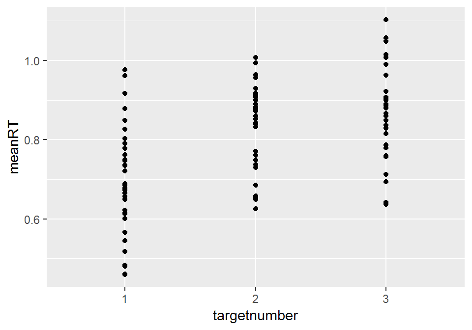

```r
#for plotting turn targetnumber and targetoccurence into factors
SummaryMeasures$targetnumber <- factor(SummaryMeasures$targetnumber)
SummaryMeasures$targetoccurence <- factor(SummaryMeasures$targetoccurence)

#Example 1: plot RTs for each targetnumber
ggplot(data=SummaryMeasures, aes(y=meanRT, x=targetnumber)) + geom_point()
```

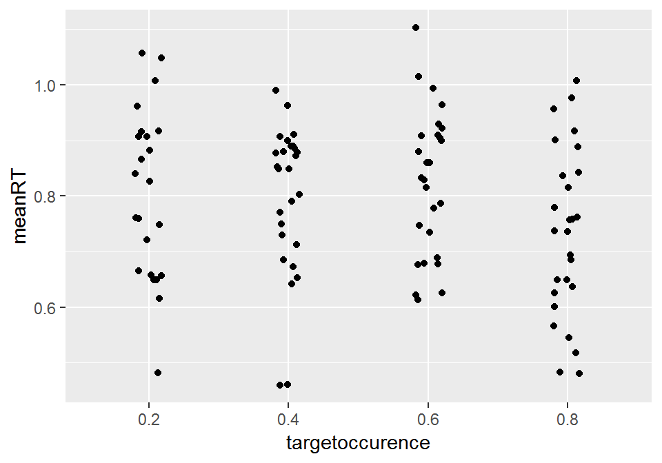

```r
#Example 2: plot RTs for each targetoccurence. This time we are going to spread the dots a little.
ggplot(data=SummaryMeasures, aes(y=meanRT, x=targetoccurence)) + geom_jitter(width=.1)
```

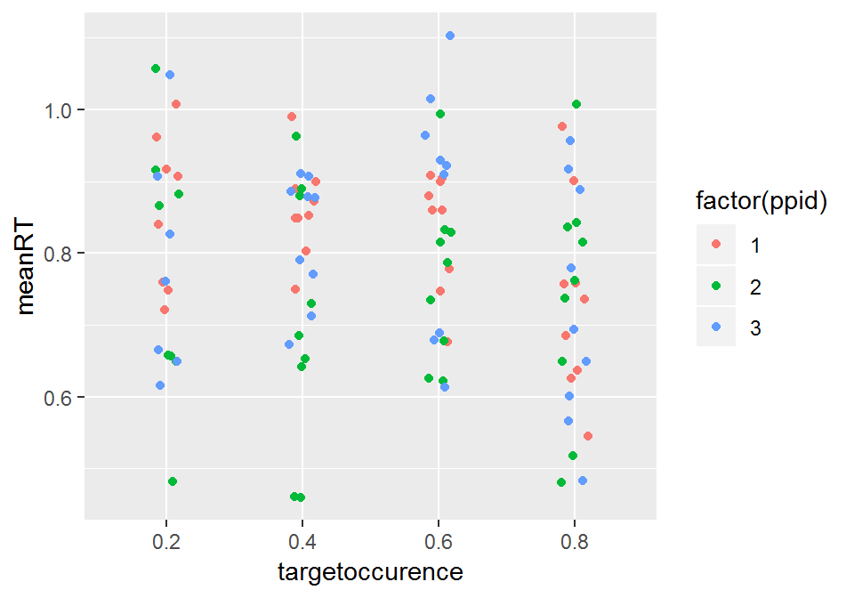

```r
#Example 3: colour them by participant
ggplot(data=SummaryMeasures, aes(y=meanRT, x=targetoccurence, color=factor(ppid))) + geom_jitter(width=.1)
```

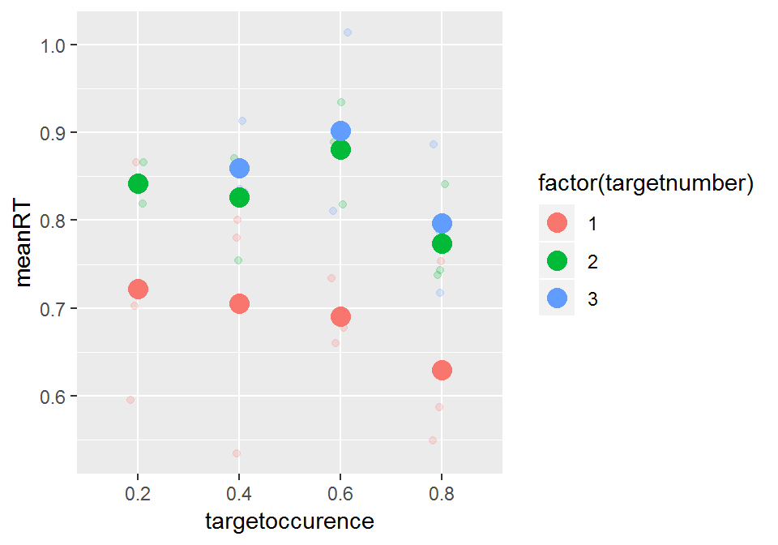

```r
#Example 4: get participant averages, but carry over important factors.
ParticipantAverages <- SummaryMeasures %>% group_by(ppid, targetnumber, targetoccurence) %>% summarise(meanRT = mean(meanRT), stdRT = mean(stdRT), counterror = mean(AvgCountError))

#plot participant averages for meanRT. with targetoccurence and number as factors
ggplot(data=ParticipantAverages, aes(y=meanRT, x=targetoccurence, color=factor(targetnumber))) + geom_jitter(width=.1, alpha = .2) + stat_summary(fun.y = "mean", geom="point", size=4)
```

Note that these are quick and dirty simple examples, and may not be the best way to display the data. They are just examples of the sorts of things you can do in R, with ggplot.